# Case Study 9

Hannah Cope

11/3/2021

#### Load Packages

```r
library(tidyverse)
library(lubridate)
```

#### Load in Data

```r
sales <- read_csv(url("https://github.com/WJC-Data-Science/DTS350/raw/master/sales.csv"))
```

### Change to Mountain Time

```r
Sales <- sales %>%
  with_tz(tzone = 'US/Mountain')
```

### Aggregate Times

```r
NewSales <- Sales %>%
  mutate(Hour = ceiling_date(Time, 'hour'),
         Day = ceiling_date(Time, 'day'),
         Month = ceiling_date(Time, 'month'))
```

### Pull Out Just the Hour Number

```r
HourSales <- NewSales %>%
  mutate(OnlyHour = format(Hour,"%H"))
```

### Plot of Sales for All of the Businesses Together Over a Day

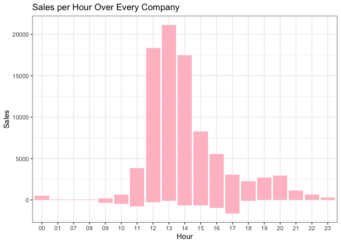

```r
ggplot(data = HourSales, aes(x = OnlyHour, y = Amount)) +
  geom_col(fill = 'pink') +
  theme_bw() +
  labs(x = "Hour",
       y = "Sales",
       title = "Sales per Hour Over Every Company")
```

This graph shows that overall, businesses should be open from 10am-9pm.

### Plot of Sales for Individual Business Over a Day

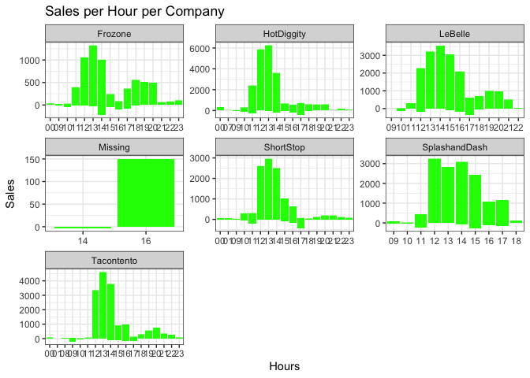

```r
ggplot(data = HourSales, aes(x = OnlyHour, y = Amount)) +
  geom_col(fill = 'green') +
  facet_wrap(~Name, scales = 'free') +
  theme_bw() +
  labs(x = "Hours",
       y = "Sales",
       title = "Sales per Hour per Company")
```

Frozone should be open from 10am-8pm. Hot Diggity should be open from 11am-5pm. LeBelle should be open from 12pm-8pm. Short Stop should be open from 12pm-4pm. Spash and Dash should be open from 12pm-5pm. Tacontento should be open from 12pm-4pm.

### Plot of Sales per Month

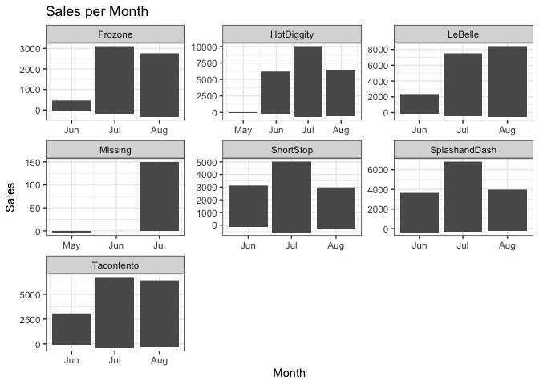

```r
ggplot(data = NewSales, aes(x = Month, y = Amount)) +
  geom_col() +
  facet_wrap(~Name, scales = 'free') +
  theme_bw() +
  labs(x = 'Month',
       y = 'Sales',
       title = 'Sales per Month')
```

This should that also all of the businesses have the most sales in July. LeBelle has the most in August.

### Plot of Sales per Company

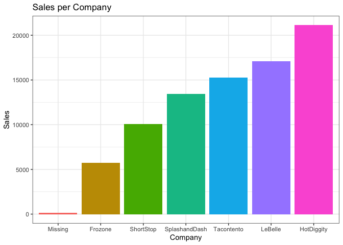

```r
NewSales2 <- NewSales %>%
  group_by(Name) %>%
  summarise(across(Amount, sum))


NewSales2 %>%
  mutate(Name = as.factor(fct_reorder(Name, Amount))) %>%
  arrange(desc(Amount)) %>%
  ggplot(aes(x = Name, y = Amount, fill = Name)) +
  geom_col() +
  theme_bw() +
  theme(legend.position = 'none') +
  labs(x = "Company",
       y = "Sales",
       title = 'Sales per Company')
```

This shows that Hot Diggity has the most sales while Missing and Frozone have the least.